# Exercise 5: Building the Training Dataframe

Group A: Eli Polzer, Matt Futia, Mia McReynolds

25 February 2021

```r
# some pathnames; yours will be specific to your CPU !!
  path.root <- "~/University of Vermont/Classes/sdhmR/sdhmR-V2021.1"

# below is the recommended class root dir
  #path.root <- "~/sdhmR-V2021.1"  # typical class root dir
  path.mod2 <- paste(path.root, "/data/module02", sep = "")
  path.figs <- paste(path.root, "/powerpoints/figures", sep = "")
  path.gis <- paste(path.root, "/data/gis_layers", sep = "")

# some libraries
  library(raster)   # FXNS: raster, projection, projectRaster, extract, crop
  library(readr)
  library(ggplot2)
  library(dplyr)
   library(sf)
```

```r
#import range-wide data
  spp106pr_RANG <- read_csv("~/University of Vermont/Classes/sdhmR/sdhmR-V2021.1/data/exercise/traindat/spp106pr_RANG.csv")

#add proj string for WGS 84
prj.wgs84 <- "+proj=longlat +ellps=WGS84 +datum=WGS84 +no_defs" # epsg:4326


#load presence/absence data
  # setwd(path.mod2) - not working?
  pres.abs <- get(load("~/University of Vermont/Classes/sdhmR/sdhmR-V2021.1/data/module02/pied.PPsA.RData"))
  # load presence:absence data
  head(pres.abs, 2) # examine
```

```
##   FNETID SPPRES106 wgs_xF wgs_yF cell.wgs_x cell.wgs_y  tr.wgs_x tr.wgs_y
## 1  13705         0     NA     NA  -111.3411   42.06001 -111.3411 42.06001
## 2  19662         0     NA     NA  -110.9996   42.02669 -110.9996 42.02669
```

```r
  load("~/University of Vermont/Classes/sdhmR/sdhmR-V2021.1/data/module02/pied.framesR.RData")

  pied.bufptR # examine cropping raster
```

```
## class      : RasterLayer
## dimensions : 1518, 1479, 2245122  (nrow, ncol, ncell)
## resolution : 0.00833, 0.00833  (x, y)
## extent     : -114.619, -102.2989, 29.4942, 42.13914  (xmin, xmax, ymin, ymax)
## crs        : +proj=longlat +ellps=WGS84 +no_defs
## source     : memory
## names      : layer
## values     : 1, 1  (min, max)
```

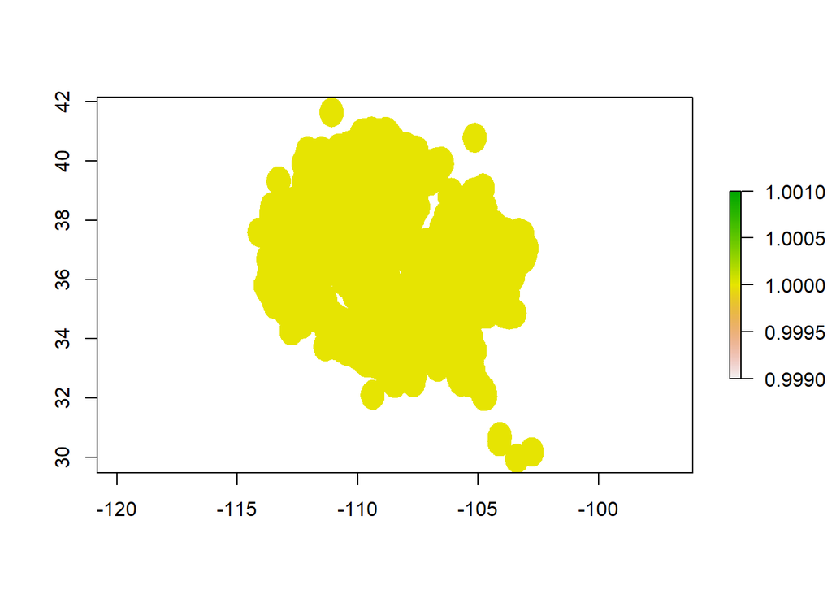

```r
  plot(pied.bufptR) # examine raster plot
```

## The Data

- Common piñon *Pinus edulis* sppcode=106
- The pseudo-absence data: Wherever stored from Homework #4
- Predictors: **`~\sdhmR-V2020.2\data\exercise\preds`**
  - There are a total of 16 predictor variables the directory above
  - The variables are **`.img`** files
- Data files:
  - **`spp106pr_MORT.csv`**, **`spp106pr_PERS.csv`**, **`spp106pr_RANG.csv`**, **`spp106pr_SEED.csv`**

## Question #1

- Import the predictor GIS variables into R

```r
#run this entire chunk at one time
 setwd("~/University of Vermont/Classes/sdhmR/sdhmR-V2021.1/data/exercise/preds")
img.list <- list.files(pattern = ".img$") # list of .img files; $ strips extra
img.list # examine
```

```
##  [1] "etpt_5.img"     "etpt_6.img"     "etpt_sprin.img" "exp1nrm.img"
##  [5] "exp3nrm.img"    "exp5nrm.img"    "mind_yr_av.img" "prad_sw_di.img"
##  [9] "prec_w_hal.img" "prec_winte.img" "rough_1k.img"   "tave_s_hal.img"
## [13] "tave_sprin.img" "tmax_s_hal.img" "tmax_summe.img" "topos.img"
```

```r
# loop for extracting topo data w/raster stack
  layers <- {} # initialize (empty) list of raster layers
  for (i in 1:length(img.list)) {
    r1 <- crop(raster(img.list[i]), pied.bufptR) # crop pred var raster to buffer raster
    names(r1) <- strsplit(img.list[i], "_wgs.img") # assign name to raster
   layers <- c(layers, r1) # add raster to layer of rasters
  }
  layers # examine raster stack; return is a list of raster layers
```

```
## [[1]]
## class      : RasterLayer
## dimensions : 1518, 1478, 2243604  (nrow, ncol, ncell)
## resolution : 0.008333333, 0.008333333  (x, y)
## extent     : -114.6167, -102.3, 29.49167, 42.14167  (xmin, xmax, ymin, ymax)
## crs        : +proj=longlat +ellps=WGS84 +no_defs
## source     : C:/Users/miamc/Documents/University of Vermont/Classes/sdhmR/sdhmR-V2021.1/data/exercise/preds/etpt_5.img
## names      : etpt_5.img
## values     : 0, 100  (min, max)
##
##
## [[2]]
## class      : RasterLayer
## dimensions : 1518, 1478, 2243604  (nrow, ncol, ncell)
## resolution : 0.008333333, 0.008333333  (x, y)
## extent     : -114.6167, -102.3, 29.49167, 42.14167  (xmin, xmax, ymin, ymax)
## crs        : +proj=longlat +ellps=WGS84 +no_defs
## source     : C:/Users/miamc/Documents/University of Vermont/Classes/sdhmR/sdhmR-V2021.1/data/exercise/preds/etpt_6.img
## names      : etpt_6.img
## values     : 69, 104  (min, max)
##
##
## [[3]]
## class      : RasterLayer
## dimensions : 1518, 1478, 2243604  (nrow, ncol, ncell)
## resolution : 0.008333333, 0.008333333  (x, y)
## extent     : -114.6167, -102.3, 29.49167, 42.14167  (xmin, xmax, ymin, ymax)
## crs        : +proj=longlat +ellps=WGS84 +no_defs
## source     : C:/Users/miamc/Documents/University of Vermont/Classes/sdhmR/sdhmR-V2021.1/data/exercise/preds/etpt_sprin.img
## names      : etpt_sprin.img
## values     : 0, 90.33334  (min, max)
##
##
## [[4]]
## class      : RasterLayer
## dimensions : 1518, 1478, 2243604  (nrow, ncol, ncell)
## resolution : 0.008333333, 0.008333333  (x, y)
## extent     : -114.6167, -102.3, 29.49167, 42.14167  (xmin, xmax, ymin, ymax)
## crs        : +proj=longlat +ellps=WGS84 +no_defs
## source     : C:/Users/miamc/Documents/University of Vermont/Classes/sdhmR/sdhmR-V2021.1/data/exercise/preds/exp1nrm.img
```

[output cut: 119 more lines]

```
## crs        : +proj=longlat +ellps=WGS84 +no_defs
## source     : C:/Users/miamc/Documents/University of Vermont/Classes/sdhmR/sdhmR-V2021.1/data/exercise/preds/tmax_summe.img
## names      : tmax_summe.img
## values     : 100, 424  (min, max)
##
##
## [[16]]
## class      : RasterLayer
## dimensions : 1518, 1478, 2243604  (nrow, ncol, ncell)
## resolution : 0.008333333, 0.008333333  (x, y)
## extent     : -114.6167, -102.3, 29.49167, 42.14167  (xmin, xmax, ymin, ymax)
## crs        : +proj=longlat +ellps=WGS84 +no_defs
## source     : C:/Users/miamc/Documents/University of Vermont/Classes/sdhmR/sdhmR-V2021.1/data/exercise/preds/topos.img
## names      : topos.img
## values     : -322.3077, 334  (min, max)
```

It looks like all CRS’s of rasters are WGS84, so I won’t have to re-project. Also all resolutions are the same, 0.0083 x 0.0083.

## Question #2

- Extract predictor variables from all 16 **`.img`** files using the presence:absence [X,Y]’s

```r
# build the raster stack
  pied.topoDOM <- stack(layers) # create a raster stack
  pied.topoDOM # examine stack
```

```
## class      : RasterStack
## dimensions : 1518, 1478, 2243604, 16  (nrow, ncol, ncell, nlayers)
## resolution : 0.008333333, 0.008333333  (x, y)
## extent     : -114.6167, -102.3, 29.49167, 42.14167  (xmin, xmax, ymin, ymax)
## crs        : +proj=longlat +ellps=WGS84 +no_defs
## names      :   etpt_5.img,   etpt_6.img, etpt_sprin.img,  exp1nrm.img,  exp3nrm.img,  exp5nrm.img, mind_yr_av.img, prad_sw_di.img, prec_w_hal.img, prec_winte.img, rough_1k.img, tave_s_hal.img, tave_sprin.img, tmax_s_hal.img, tmax_summe.img, ...
## min values :     0.000000,    69.000000,       0.000000, -1152.000000,  -812.000000,  -715.000000,   -2294.333252,    6411.166016,       3.666667,       3.333333,     0.000000,      16.166666,     -86.000000,      63.833332,     100.000000, ...
## max values :    100.00000,    104.00000,       90.33334,   1246.00000,    945.00000,    895.00000,      249.33333,    14441.50000,      136.83333,      140.33333,    243.85391,      308.33334,      226.66667,      392.33334,      424.00000, ...
```

```r
# extract from stack
  t1 <- extract(pied.topoDOM, pres.abs[, c("tr.wgs_x", "tr.wgs_y")]) # extract values from raster stack
  head(t1, 2) # examine extracted matrix
```

```
##      etpt_5.img etpt_6.img etpt_sprin.img exp1nrm.img exp3nrm.img exp5nrm.img
## [1,]         89         98       51.33333           0           0           0
## [2,]         87         97       47.33333         -26          -9          17
##      mind_yr_av.img prad_sw_di.img prec_w_hal.img prec_winte.img rough_1k.img
## [1,]      -1098.833        12214.5       27.33333       26.00000      0.00000
## [2,]      -1092.750        11990.0       22.50000       20.33333     27.77801
##      tave_s_hal.img tave_sprin.img tmax_s_hal.img tmax_summe.img topos.img
## [1,]            130             41       223.0000       263.3333 -1.923077
## [2,]            115             24       210.6667       251.0000  2.230769
```

Looks good: all 16 rasters are there, and resolution/CRS are preserved.

## Question #3

- Create a new dataframe by binding the extracted predictor variable values to the dataframe from exercise #4.

```r
  pied.trTOPO <- cbind(pres.abs, t1) %>% # bind to train dataframe
    select(-c(wgs_xF, wgs_yF, cell.wgs_x, cell.wgs_y))

  head(pied.trTOPO, 2) # examine training data frame
```

```
##   FNETID SPPRES106  tr.wgs_x tr.wgs_y etpt_5.img etpt_6.img etpt_sprin.img
## 1  13705         0 -111.3411 42.06001         89         98       51.33333
## 2  19662         0 -110.9996 42.02669         87         97       47.33333
##   exp1nrm.img exp3nrm.img exp5nrm.img mind_yr_av.img prad_sw_di.img
## 1           0           0           0      -1098.833        12214.5
## 2         -26          -9          17      -1092.750        11990.0
##   prec_w_hal.img prec_winte.img rough_1k.img tave_s_hal.img tave_sprin.img
## 1       27.33333       26.00000      0.00000            130             41
## 2       22.50000       20.33333     27.77801            115             24
##   tmax_s_hal.img tmax_summe.img topos.img
## 1       223.0000       263.3333 -1.923077
## 2       210.6667       251.0000  2.230769
```

I removed the wgs_xF and cell.wgs_x columns, since all coords are in tr.wgs_x.

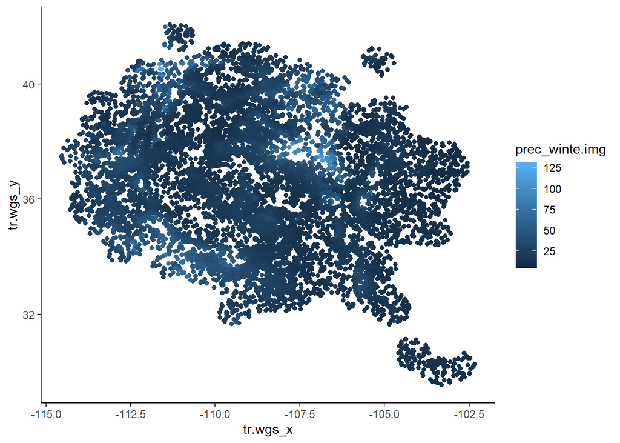

```r
ggplot(pied.trTOPO, aes(x=tr.wgs_x, y=tr.wgs_y)) +
  geom_point(aes(color=prec_winte.img)) +
  theme_classic()
```

A plot for fun, winter precipitation. Looks reasonable.

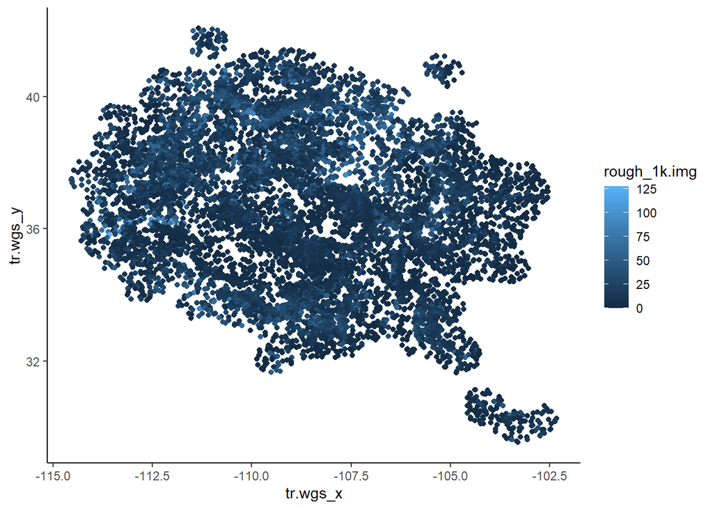

```r
ggplot(pied.trTOPO, aes(x=tr.wgs_x, y=tr.wgs_y)) +
  geom_point(aes(color=rough_1k.img)) +
  theme_classic()
```

Assuming this is some kind of elevation layer? Looks like some of these predictors will be correlated.

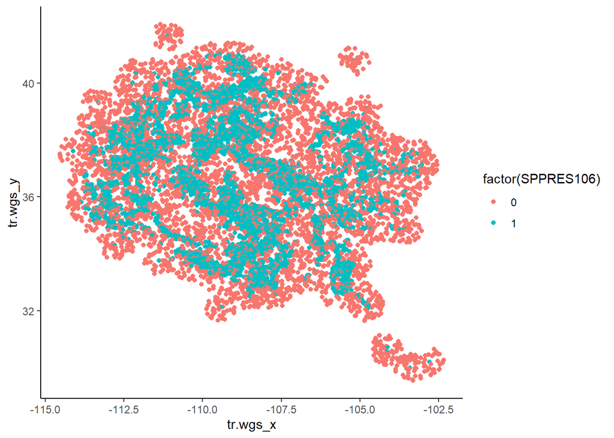

```r
ggplot(pied.trTOPO, aes(x=tr.wgs_x, y=tr.wgs_y)) +
  geom_point(aes(color=factor(SPPRES106))) +
  theme_classic()
```

## Question #4

- Save your data as R objects:
  - Dataframe;
  - Point shapefile with geometry in R
  - Export as a point shapefile in ESRI format
- Save these R objects in a **`.RData`** file

These data will be used in the next exercise #6.

```r
# write out data files if desired
  setwd(path.mod2)
  write.csv(pied.trTOPO, file = "pied_trTOPO.csv", row.names = F) # save .csv - training data
  save(pied.trTOPO, file = "pied.trTOPO.RData") # save .RData - pres/abs plus stacked raster
  save(pied.topoDOM, file = "pied.topoDOM.RData") # save .RData - stacked raster
  st_write(pied.trTOPO, dsn = ".", layer = "pied.trTOPO", driver = "ESRI Shapefile",
    delete_layer = T, delete_dsn = T)#point shapefile in ESRI format
```

```
## Deleting source `.' using driver `ESRI Shapefile'
## Writing layer `pied.trTOPO' to data source `.' using driver `ESRI Shapefile'
## Writing 10066 features with 20 fields without geometries.
```